# Анализ акций российских нефтяных компаний

## Оглавление

1. **Импорт необходимых библиотек**
   - Подключение библиотек для анализа данных, работы с датами и API MOEX.
2. **Вспомогательные функции**
3. **Получение данных**
4. **EDA**
   - Проверка пропущенных значений и их обработка.
   - Базовая статистика.
   - Визуализация временных рядов.
   - Тестирование временных рядов на стационарность.
   - Построение корреляционной матрицы цен акций.
5. **Обработка временных рядов**
   - Перевод временных рядов в стационарные путём вычисления процентных изменений.
   - Рассчёт основных статистик доходности акций.
   - Визуальная оценка распределения доходностей акций.
   - Корреляционная матрица доходностей акций.
   - Анализ автокорреляции (ACF) и частичной автокорреляции (PACF).
6. **Анализ волатильности**
   - Годовая скользящая волатильность в разных временных окнах.
   - Статистика по скользящей волатильности.
7. **Анализ месячных доходностей**
   - Ресэмплирование данных на месячные доходности.
   - Статистика по месячным доходностям.
   - Корреляционная матрица месячных доходностей.
8. **Динамика корреляции между акциями**
   - Анализ динамики корреляции доходностей акций в рамках года (252 дня).

## 1. Импорт необходимых библиотек

```python
import pandas as pd
import numpy as np
from matplotlib import pyplot as plt
import seaborn as sns
from datetime import date, datetime, timedelta
import apimoex
import requests
import time
from statsmodels.tsa.stattools import adfuller, acf, pacf
from scipy.interpolate import CubicSpline
```

## 2. Вспомогательные функции

- `parse_date` - преобразует строку даты в объект `date`

```python
def parse_date(date_input: str|date) -> date:
    if isinstance(date_input, str):
        return datetime.strptime(date_input, '%Y-%m-%d').date()
    return date_input
```

- `add_suffix` - добавляет суффикс к каждому элементу списка

```python
def add_suffix(lst: list, suffix: str) -> list:
    return [s + suffix for s in lst]
```

- `get_moex_stock` - получает данные о ценах акции (тикера) с MOEX за определенный временной промежуток

Реализовано деление на несколько запросов, в случае если длина запрашиваемого диапазона слишком большая

```python
def get_moex_stock(ticker: str, start: str, end: str, chunk_size: int = 1000) -> pd.DataFrame:
    all_data = []
    start = parse_date(start)
    end = parse_date(end)

    with requests.Session() as session:
        current_start = start
        while current_start <= end:
            current_end = min(current_start + timedelta(days=chunk_size), end)
            chunk_data = apimoex.get_market_candles(
                session=session,
                security=ticker,
                start=current_start.strftime('%Y-%m-%d'),
                end=current_end.strftime('%Y-%m-%d')
            )

            if chunk_data:
                df_chunk = pd.DataFrame(chunk_data)
                all_data.append(df_chunk)

            current_start = current_end + timedelta(days=1)
            time.sleep(1)  # Not being greedy :)

    if not all_data:
        return pd.DataFrame()

    df = pd.concat(all_data, ignore_index=True)
    df['begin'] = pd.to_datetime(df['begin']).dt.date
    df.rename({'begin': 'date', 'value': 'volume'}, axis='columns', inplace=True)
    df.set_index('date', inplace=True)
    df = df.sort_index()
    multi_index = pd.MultiIndex.from_tuples([(ticker, col) for col in df.columns], names=['Ticker', 'Indicator'])
    df.columns = multi_index

    return df
```

- `cubic_spline_interpolate` - интерполирует пропущенные значения с помощью кубических сплайнов

```python
def cubic_spline_interpolate(column: pd.Series) -> pd.Series:
    valid_data = column.dropna()
    if len(valid_data) < 2:
        return column
    cs = CubicSpline(valid_data.index.astype(np.int64), valid_data.values)
    return pd.Series(cs(column.index.astype(np.int64)), index=column.index)
```

- `adf_test`: Проводит ADF тест на стационарность временного ряда.

```python
def adf_test(series: pd.Series) -> float:
    result = adfuller(series.dropna(), autolag='AIC')
    return round(result[1], 3)
```

## 3. Получение данных

Список выбранных нами тикеров компаний

```python
tickers_lst = ['LKOH', 'ROSN', 'SIBN', 'SNGS', 'TATN']
start_date = '2005-01-01'
end_date = date.today().strftime('%Y-%m-%d')
```

Получение данных с помощью API MOEX

```python
# Will take some time (~ 45s)

# df_res = pd.DataFrame()
# for ticker in tickers_lst:
#     temp_df = get_moex_stock(ticker, start_date, end_date)
#     if df_res.empty:
#         df_res = temp_df
#         continue
#     df_res = df_res.merge(temp_df, how='outer', left_index=True, right_index=True)

# df_res.to_pickle('df_tickers.pkl')
```

```python
df_res = pd.read_pickle('df_tickers.pkl')
df_res = df_res.set_index(pd.to_datetime(df_res.index))
```

Далее будем рассматривать только цены закрытия

```python
df: pd.DataFrame = df_res.loc[:, (slice(None), 'close')]
df.columns = df.columns.droplevel('Indicator')
```

## 4. EDA

### Проверка пропущенных значений

Определение первой даты с полными данными - от нее и будем отталкиваться

```python
first_valid_date = df.apply(lambda x: x.first_valid_index()).max()
df = df.loc[first_valid_date:]

first_valid_date.strftime(f'%d.%m.%Y')
```

```
'19.07.2006'
```

Смотрим на пропуски

```python
df.isna().sum()
```

```
Ticker
LKOH    0
ROSN    0
SIBN    2
SNGS    0
TATN    2
dtype: int64
```

```python
# Восполним недостающие временные метки
dates = pd.date_range(start=df.index[0], end=df.index[-1])
df_plot = df.reindex(dates)

# Методологически при работе с финансовыми данными лучше использовать только реальные данные
# поэтому лучше просто удалить пропуски
# Потом можно будет оценить, какой вариант лучше
df = df.dropna()
```

### Базовая статистика

```python
df.describe()
```

| Ticker | LKOH | ROSN | SIBN | SNGS | TATN |
| --- | --- | --- | --- | --- | --- |
| count | 4576.000000 | 4576.000000 | 4576.000000 | 4576.000000 | 4576.000000 |
| mean | 3383.818982 | 318.520686 | 259.372113 | 29.371795 | 350.147297 |
| std | 1832.761519 | 123.408088 | 180.948354 | 5.559763 | 213.930696 |
| min | 740.220000 | 82.410000 | 40.150000 | 8.701000 | 27.500000 |
| 25% | 1921.575000 | 224.000000 | 135.667500 | 26.105000 | 157.575000 |
| 50% | 2559.000000 | 265.290000 | 157.000000 | 28.617500 | 310.000000 |
| 75% | 4880.625000 | 399.675000 | 362.500000 | 32.796250 | 514.050000 |
| max | 8152.000000 | 655.250000 | 934.250000 | 54.170000 | 837.000000 |

### Визуализация временных рядов

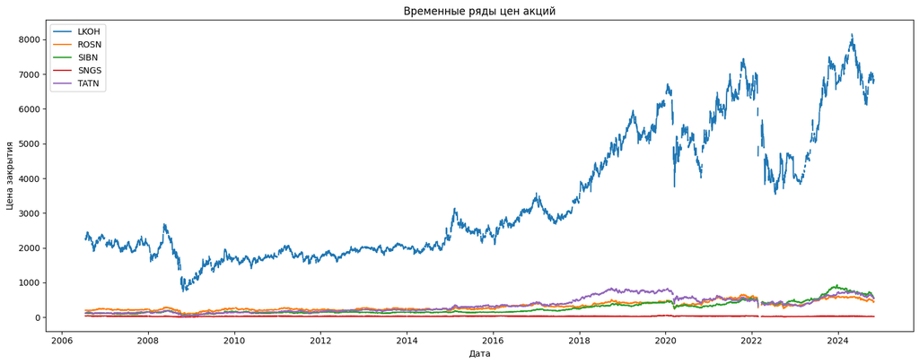

```python
plt.figure(figsize=(15, 6))
for column in tickers_lst:
    plt.plot(df_plot.index, df_plot[column], label=column)
plt.title("Временные ряды цен акций")
plt.xlabel("Дата")
plt.ylabel("Цена закрытия")
plt.legend()
plt.tight_layout()
# Приостановка торгов в 2022 году
# plt.xlim((pd.to_datetime('2022-01-01').date(), pd.to_datetime('2022-04-01').date()))
plt.show()
```

Посмотрим на нормализованные цены (индекс цен, где базовым является первое значение)

- Так будет лучше видна динамика акций

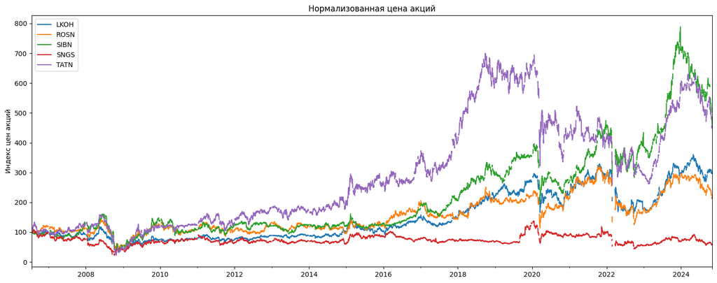

```python
normalized = df_plot / df_plot.iloc[0] * 100
normalized.plot(figsize=(15, 6))
plt.title('Нормализованная цена акций')
plt.ylabel('Индекс цен акций')
plt.legend()
plt.tight_layout()
plt.show()
```

### Тестирование временных рядов на стационарность

```python
df[tickers_lst].apply(adf_test)
```

```
Ticker
LKOH    0.818
ROSN    0.433
SIBN    0.758
SNGS    0.000
TATN    0.672
dtype: float64
```

### Построение корреляционной матрицы цен акций

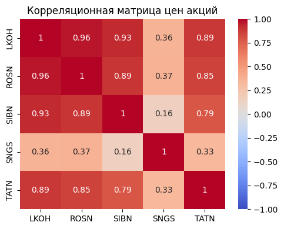

```python
plt.figure(figsize=(5, 4))
correlation_matrix = df.corr()
sns.heatmap(correlation_matrix, annot=True, cmap='coolwarm', vmin=-1, vmax=1)
plt.title("Корреляционная матрица цен акций")
plt.xlabel('')
plt.ylabel('')
plt.tight_layout()
plt.show()
```

**Вывод:**

В целом, акции компаний исторически показывали схожую динамику

## 5. Обработка временных рядов

### Перевод временных рядов в стационарные

Перейдем к процентным изменениям в ценах акций

- Это позволит сразу прийти к стационарным рядам
- Эквивалентно взятию разности логарифмов

```python
df_pct = df.pct_change()
df_pct.apply(adf_test)
```

```
Ticker
LKOH    0.0
ROSN    0.0
SIBN    0.0
SNGS    0.0
TATN    0.0
dtype: float64
```

### Рассчёт основных статистик доходности акций

```python
pd.DataFrame({
    'Mean Return (%)': (df_pct.mean() * 100).round(2),
    'Volatility (%)': (df_pct.std() * 100).round(2),
    'Skewness': df_pct.skew().round(2),
    'Kurtosis': df_pct.kurtosis().round(2)
})
```

| Ticker | Mean Return (%) | Volatility (%) | Skewness | Kurtosis |
| --- | --- | --- | --- | --- |
| LKOH | 0.05 | 2.20 | 0.14 | 18.73 |
| ROSN | 0.05 | 2.41 | 1.06 | 55.04 |
| SIBN | 0.06 | 2.10 | -0.47 | 17.60 |
| SNGS | 0.02 | 2.53 | 1.86 | 42.27 |
| TATN | 0.07 | 2.66 | 0.90 | 25.47 |

### Визуальная оценка распределения доходностей акций

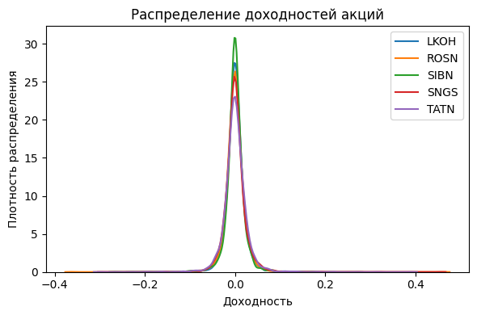

```python
plt.figure(figsize=(6, 4))

for ticker in df_pct.columns:
    sns.kdeplot(data=df_pct[ticker].dropna(), label=ticker, common_norm=False)

plt.xlabel('Доходность')
plt.ylabel('Плотность распределения')
plt.title('Распределение доходностей акций')
plt.legend()
plt.tight_layout()
plt.show()
```

### Корреляционная матрица доходностей акций

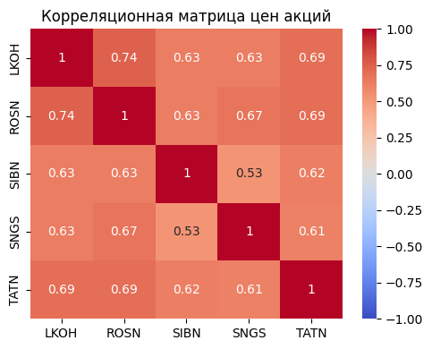

```python
plt.figure(figsize=(5, 4))
correlation_matrix = df_pct.corr()
sns.heatmap(correlation_matrix, annot=True, cmap='coolwarm', vmin=-1, vmax=1)
plt.title("Корреляционная матрица цен акций")
plt.xlabel('')
plt.ylabel('')
plt.tight_layout()
plt.show()
```

**Вывод:**

Доходности акций также сильно коррелируют

### Анализ автокорреляции (ACF) и частичной автокорреляции (PACF)

Графики ACF и PACF построены без нулевого лага (равного 1) для улучшения читаемости

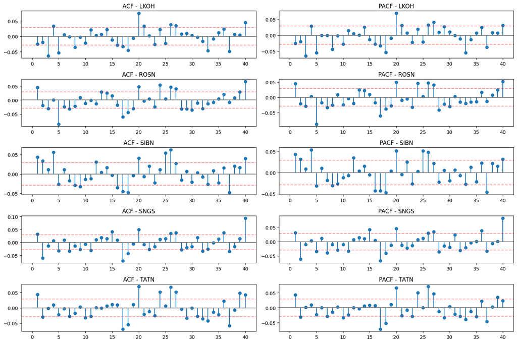

```python
lags = 40
fig, axes = plt.subplots(len(df_pct.columns), 2, figsize=(15, 2*len(df_pct.columns)))

for idx, ticker in enumerate(df_pct.columns):
    series = df_pct[ticker].dropna()

    # ACF
    acf_values = acf(series, nlags=lags)
    acf_values[0] = np.nan
    axes[idx, 0].stem(range(len(acf_values)), acf_values)
    axes[idx, 0].set_title(f'ACF - {ticker}')
    axes[idx, 0].axhline(y=0, linestyle='-', color='gray')
    axes[idx, 0].axhline(y=-1.96/np.sqrt(len(series)), linestyle='--', color='red', alpha=0.4)
    axes[idx, 0].axhline(y=1.96/np.sqrt(len(series)), linestyle='--', color='red', alpha=0.4)

    # PACF
    pacf_values = pacf(series, nlags=lags)
    pacf_values[0] = np.nan
    axes[idx, 1].stem(range(len(pacf_values)), pacf_values)
    axes[idx, 1].set_title(f'PACF - {ticker}')
    axes[idx, 1].axhline(y=0, linestyle='-', color='gray')
    axes[idx, 1].axhline(y=-1.96/np.sqrt(len(series)), linestyle='--', color='red', alpha=0.4)
    axes[idx, 1].axhline(y=1.96/np.sqrt(len(series)), linestyle='--', color='red', alpha=0.4)

plt.tight_layout()
plt.show()
```

## 6. Анализ волатильности

### Годовая скользящая волатильность в разных временных окнах

Выбранные ременные окна (`vol_window`): 30 дней (месяц) и 252 дня (год торгов). Волатильность выражена в процентах в годовом выражении.

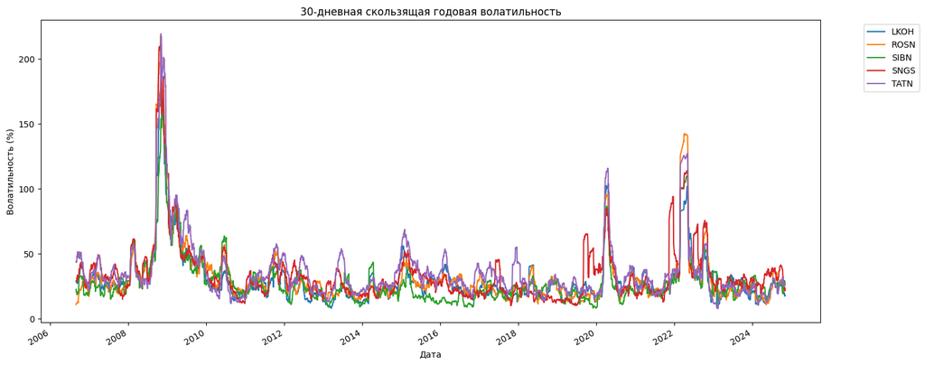

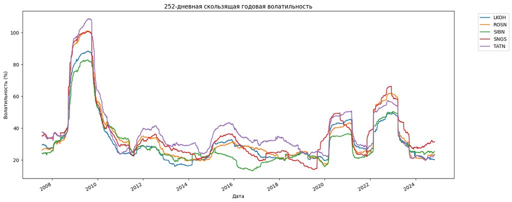

```python
vol_window = 30
rolling_vol = df_pct.rolling(window=vol_window).std() * np.sqrt(252) * 100
rolling_vol.plot(figsize=(15, 6))
plt.title(f'{vol_window}-дневная скользящая годовая волатильность')
plt.xlabel('Дата')
plt.ylabel('Волатильность (%)')
plt.legend(bbox_to_anchor=(1.05, 1), loc='upper left')
plt.tight_layout()
plt.show()

vol_window = 252
rolling_vol = df_pct.rolling(window=vol_window).std() * np.sqrt(252) * 100
rolling_vol.plot(figsize=(15, 6))
plt.title(f'{vol_window}-дневная скользящая годовая волатильность')
plt.xlabel('Дата')
plt.ylabel('Волатильность (%)')
plt.legend(bbox_to_anchor=(1.05, 1), loc='upper left')
plt.tight_layout()
plt.show()
```

### Статистика по скользящей волатильности

```python
rolling_vol.describe()
```

| Ticker | LKOH | ROSN | SIBN | SNGS | TATN |
| --- | --- | --- | --- | --- | --- |
| count | 4324.000000 | 4324.000000 | 4324.000000 | 4324.000000 | 4324.000000 |
| mean | 31.713575 | 34.170083 | 30.268598 | 36.077299 | 38.472926 |
| std | 15.690813 | 18.608306 | 15.069693 | 18.544078 | 18.498001 |
| min | 15.977867 | 16.944699 | 13.173589 | 13.822295 | 19.711315 |
| 25% | 21.916857 | 23.059640 | 21.670080 | 24.726470 | 28.669251 |
| 50% | 27.320742 | 27.604020 | 24.558434 | 31.022378 | 32.479014 |
| 75% | 32.959868 | 35.375527 | 34.571130 | 38.551935 | 41.471495 |
| max | 88.544384 | 101.140742 | 82.899255 | 100.899370 | 108.806568 |

## 7. Анализ месячных доходностей

### Ресэмплирование данных на месячные доходности.

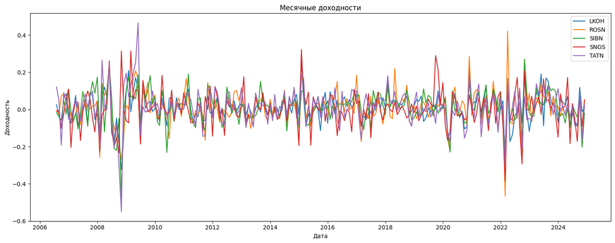

```python
monthly_returns = df_pct.resample('ME').apply(lambda x: (1 + x).prod() - 1)

plt.figure(figsize=(15, 6))
for column in monthly_returns.columns:
    plt.plot(monthly_returns.index, monthly_returns[column], label=column)
plt.title("Месячные доходности")
plt.xlabel("Дата")
plt.ylabel("Доходность")
plt.legend()
plt.tight_layout()
plt.show()
```

### Статистика по месячным доходностям

```python
monthly_returns.describe()
```

| Ticker | LKOH | ROSN | SIBN | SNGS | TATN |
| --- | --- | --- | --- | --- | --- |
| count | 221.000000 | 221.000000 | 221.000000 | 221.000000 | 221.000000 |
| mean | 0.008394 | 0.008601 | 0.011161 | 0.002608 | 0.012463 |
| std | 0.081480 | 0.097530 | 0.088525 | 0.098380 | 0.101354 |
| min | -0.325000 | -0.466245 | -0.481347 | -0.386258 | -0.549585 |
| 25% | -0.029105 | -0.037005 | -0.035569 | -0.047168 | -0.041560 |
| 50% | 0.009212 | 0.010208 | 0.012721 | 0.006063 | 0.015573 |
| 75% | 0.053381 | 0.055607 | 0.067410 | 0.053689 | 0.070068 |
| max | 0.253888 | 0.420685 | 0.270661 | 0.322279 | 0.466361 |

### Корреляционная матрица месячных доходностей

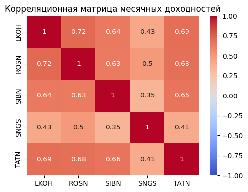

```python
plt.figure(figsize=(5, 4))
correlation_matrix = monthly_returns.corr()
sns.heatmap(correlation_matrix, annot=True, cmap='coolwarm', vmin=-1, vmax=1)
plt.title('Корреляционная матрица месячных доходностей')
plt.xlabel('')
plt.ylabel('')
plt.tight_layout()
plt.show()
```

## 8. Динамика корреляции между акциями

### Анализ динамики корреляции доходностей акций в рамках года (252 дня)

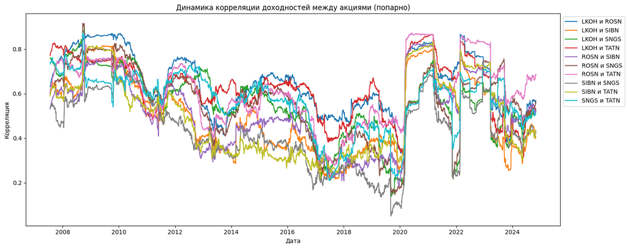

```python
rolling_corr = pd.DataFrame()
window_size = 252

for ticker1 in df_pct.columns:
    for ticker2 in df_pct.columns:
        if ticker1 < ticker2:  # берем только уникальные пары
            corr = df_pct[ticker1].rolling(window=window_size).corr(df_pct[ticker2])
            rolling_corr[f'{ticker1} и {ticker2}'] = corr

plt.figure(figsize=(15, 6))
for column in rolling_corr.columns:
    plt.plot(rolling_corr.index, rolling_corr[column], label=column)
plt.title("Динамика корреляции доходностей между акциями (попарно)")
plt.xlabel("Дата")
plt.ylabel("Корреляция")
plt.legend(bbox_to_anchor=(1, 1))
plt.tight_layout()
plt.show()
```